# HotelBookings

# cancelation based on avergae price of a room

```python
cancellation_by_reserved_price = round(data.groupby(['is_canceled','reserved_room_type'])['adr'].mean()*100).reset_index()
cancellation_by_reserved_price
```

|  | is_canceled | reserved_room_type | adr |
| --- | --- | --- | --- |
| 0 | 0 | A | 8916.0 |
| 1 | 0 | B | 8742.0 |
| 2 | 0 | C | 15302.0 |
| 3 | 0 | D | 11637.0 |
| 4 | 0 | E | 11907.0 |
| 5 | 0 | F | 15924.0 |
| 6 | 0 | G | 16924.0 |
| 7 | 0 | H | 18087.0 |
| 8 | 0 | L | 15100.0 |
| 9 | 1 | A | 9335.0 |
| 10 | 1 | B | 9634.0 |
| 11 | 1 | C | 17480.0 |
| 12 | 1 | D | 12994.0 |
| 13 | 1 | E | 13775.0 |
| 14 | 1 | F | 18705.0 |
| 15 | 1 | G | 18779.0 |
| 16 | 1 | H | 19891.0 |
| 17 | 1 | L | 7200.0 |
| 18 | 1 | P | 0.0 |

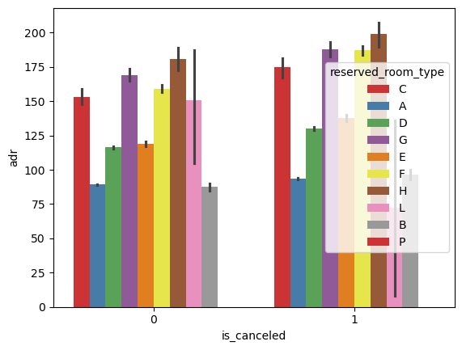

```python
sns.barplot(x = 'is_canceled', y = 'adr', data = data , hue='reserved_room_type', palette="Set1")
```

```python
cancellation_by_assigned_price = round(data.groupby(['is_canceled','assigned_room_type'])['adr'].mean()*100)
cancellation_by_assigned_price
```

```
is_canceled  assigned_room_type
0            A                      9268.0
             B                      9447.0
             C                     10653.0
             D                     10082.0
             E                     11146.0
             F                     14203.0
             G                     15786.0
             H                     15796.0
             I                      4011.0
             K                      5277.0
1            A                      9371.0
             B                      9440.0
             C                     14323.0
             D                     12723.0
             E                     13624.0
             F                     18194.0
             G                     18623.0
             H                     19603.0
             I                      9370.0
             K                      7426.0
             L                       800.0
             P                         0.0
Name: adr, dtype: float64
```

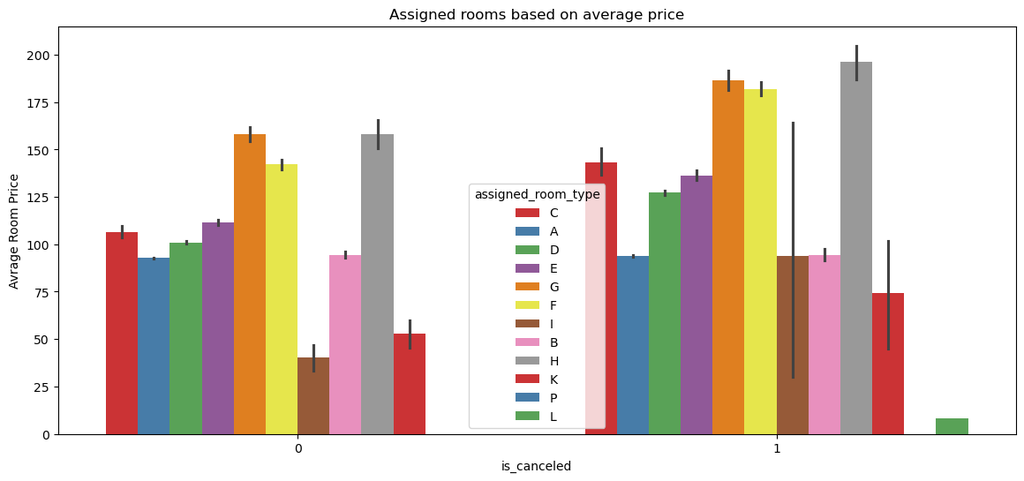

```python
plt.figure(figsize=(14,6))
sns.barplot(x = 'is_canceled', y = 'adr', data = data ,hue='assigned_room_type', palette="Set1")
plt.ylabel('Avrage Room Price')
plt.title("Assigned rooms based on average price")
```

```python
#it’s unlikely that hotels deliberately raise prices for
#rooms that are likely to be canceled. The discrepancy is more likely due to complex pricing dynamics, booking behaviors,
#or the nature of the specific dataset you're analyzing.
# check when and why cancellations happen (e.g., look at booking lead time, seasonality, or room type trends)
```

```python
# Group by 'is_canceled' and check the average lead time for canceled vs non-canceled bookings
lead_time_by_cancellation = data.groupby('is_canceled')['lead_time'].mean().reset_index()

# Display the result
lead_time_by_cancellation
```

|  | is_canceled | lead_time |
| --- | --- | --- |
| 0 | 0 | 79.984687 |
| 1 | 1 | 144.848815 |

```python
#Longer lead time correlates with higher prices: People booking earlier may lock in higher prices,
#especially if they are booking for peak periods. Hotels might charge a premium for early bookings or during high-demand seasons.
```

# 2. Customer Demographics

Task 1:What kind of customers do we attract? Specifically, what are the most common customer demographics (age groups, countries, etc.)?

```python
data['customer_type'].unique()
```

```
array(['Transient', 'Contract', 'Transient-Party', 'Group'], dtype=object)
```

Transient – This means guests who stay for a short time, like one or two nights. They don't plan to stay long or don’t have any special deals.

Transient-Party – This is for guests who are part of a small group or family but are still staying for a short time, similar to transient guests.

Group – This refers to larger groups, like for events or conferences, where many people book rooms together.

Contract – These are guests who have a special long-term deal or contract with the hotel, like company employees who stay for business regularly.

```python
data['customer_type'].value_counts()
```

```
customer_type
Transient          89613
Transient-Party    25124
Contract            4076
Group                577
Name: count, dtype: int64
```

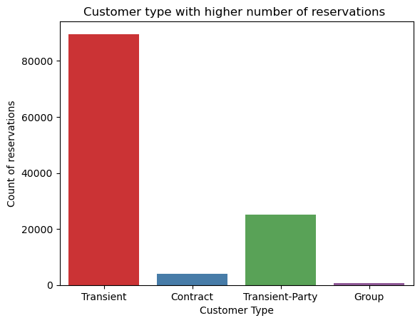

```python
sns.countplot(x='customer_type', data = data , hue='customer_type', palette='Set1')
plt.title('Customer type with higher number of reservations ')
plt.xlabel('Customer Type')
plt.ylabel('Count of reservations')
```

Task 2 most common customer demographics (age groups, countries, etc.)

```python
data['country'].unique()
```

```
array(['PRT', 'GBR', 'USA', 'ESP', 'IRL', 'FRA', nan, 'ROU', 'NOR', 'OMN',
       'ARG', 'POL', 'DEU', 'BEL', 'CHE', 'CN', 'GRC', 'ITA', 'NLD',
       'DNK', 'RUS', 'SWE', 'AUS', 'EST', 'CZE', 'BRA', 'FIN', 'MOZ',
       'BWA', 'LUX', 'SVN', 'ALB', 'IND', 'CHN', 'MEX', 'MAR', 'UKR',
       'SMR', 'LVA', 'PRI', 'SRB', 'CHL', 'AUT', 'BLR', 'LTU', 'TUR',
       'ZAF', 'AGO', 'ISR', 'CYM', 'ZMB', 'CPV', 'ZWE', 'DZA', 'KOR',
       'CRI', 'HUN', 'ARE', 'TUN', 'JAM', 'HRV', 'HKG', 'IRN', 'GEO',
       'AND', 'GIB', 'URY', 'JEY', 'CAF', 'CYP', 'COL', 'GGY', 'KWT',
       'NGA', 'MDV', 'VEN', 'SVK', 'FJI', 'KAZ', 'PAK', 'IDN', 'LBN',
       'PHL', 'SEN', 'SYC', 'AZE', 'BHR', 'NZL', 'THA', 'DOM', 'MKD',
       'MYS', 'ARM', 'JPN', 'LKA', 'CUB', 'CMR', 'BIH', 'MUS', 'COM',
       'SUR', 'UGA', 'BGR', 'CIV', 'JOR', 'SYR', 'SGP', 'BDI', 'SAU',
       'VNM', 'PLW', 'QAT', 'EGY', 'PER', 'MLT', 'MWI', 'ECU', 'MDG',
       'ISL', 'UZB', 'NPL', 'BHS', 'MAC', 'TGO', 'TWN', 'DJI', 'STP',
       'KNA', 'ETH', 'IRQ', 'HND', 'RWA', 'KHM', 'MCO', 'BGD', 'IMN',
       'TJK', 'NIC', 'BEN', 'VGB', 'TZA', 'GAB', 'GHA', 'TMP', 'GLP',
       'KEN', 'LIE', 'GNB', 'MNE', 'UMI', 'MYT', 'FRO', 'MMR', 'PAN',
       'BFA', 'LBY', 'MLI', 'NAM', 'BOL', 'PRY', 'BRB', 'ABW', 'AIA',
       'SLV', 'DMA', 'PYF', 'GUY', 'LCA', 'ATA', 'GTM', 'ASM', 'MRT',
       'NCL', 'KIR', 'SDN', 'ATF', 'SLE', 'LAO'], dtype=object)
```

```python
data['country'].value_counts()
```

```
country
PRT    48590
GBR    12129
FRA    10415
ESP     8568
DEU     7287
       ...
DJI        1
BWA        1
HND        1
VGB        1
NAM        1
Name: count, Length: 177, dtype: int64
```

```python
# converting country code to country names
country_names = {
'PRT':'Portugal','AUT': 'Austria','ESP':'Spain','ITA':'Italy','FRA':'France','DEU':'Germany','BEL':'Belgium','CZE':'Czech Republic',
'GBR':'United Kingdom','NLD':'Netherlands','USA':'United States','MEX':'Mexico','CHE':'Switzerland','AUS':'Australia','BGR':'Bulgaria','CHN':'China','ROU':'Romania',
'IRL':'Ireland'}
data['country'] = data['country'].replace(country_names)
data['country']
```

```
0               Portugal
1               Portugal
2         United Kingdom
3         United Kingdom
4         United Kingdom
               ...
119385           Belgium
119386            France
119387           Germany
119388    United Kingdom
119389           Germany
Name: country, Length: 119390, dtype: object
```

```python
# # plt.figure(figsize=(15,6))
# # sns.countplot(x = 'country', data= data,hue='country', palette='Set1')
# # plt.xticks(rotation=45)
# # plt.show()
# # import plotly.express as px

# # Drop NaN values and prepare the country data
# country_counts = data['country'].value_counts().reset_index()
# country_counts.columns = ['country', 'count']
# fig.update_layout(
#     width=1500,  # set width
#     height=1500   # set height
# )

# # Create a choropleth map using Plotly
# fig = px.choropleth(country_counts,
#                     locations='country',
#                     locationmode='ISO-3',
#                     color='count',
#                     hover_name='country',
#                     color_continuous_scale=px.colors.sequential.Plasma,
#                     title="Country-wise Hotel Reservations")

# fig.show()
```

```python
# customer based on age groups
# we will have to create seperate groups for adults, family with babies, familt with adults.
```

```python
data.columns
```

```
Index(['hotel', 'is_canceled', 'lead_time', 'arrival_date_year',
       'arrival_date_month', 'arrival_date_week_number',
       'arrival_date_day_of_month', 'stays_in_weekend_nights',
       'stays_in_week_nights', 'adults', 'children', 'babies', 'meal',
       'country', 'market_segment', 'distribution_channel',
       'is_repeated_guest', 'previous_cancellations',
       'previous_bookings_not_canceled', 'reserved_room_type',
       'assigned_room_type', 'booking_changes', 'deposit_type',
       'days_in_waiting_list', 'customer_type', 'adr',
       'required_car_parking_spaces', 'total_of_special_requests',
       'reservation_status', 'reservation_status_date', 'name', 'email',
       'phone-number', 'credit_card', 'Year', 'Month', 'lead_time_category'],
      dtype='object')
```

```python
#function to classify the age groups
def age_group_classify(row):
    if row['adults']>0 and row['children']==0 and row['babies']==0:
        return "Adults Only"
    elif row['adults']>0 and row['children']>0 and row['babies']==0:
        return "Adults with childrens"
    elif row['adults']>0 and row['children'] == 0 and row['babies']>0:
        return "Adults with babies"
    elif row['adults'] ==0 and row['children']>0 or row['babies']>0:
        return "Adults with children and babies"
    elif row['adults']==0 and row['children']>0:
        return "Children Only"
    elif row['adults']==0 and row['babies']>0:
        return "Babies Only"
    else:
        return "Other"
# create a a new column with data['age_group']
data['age_group'] = data.apply(age_group_classify,axis=1)
data['age_group']
```

```
0         Adults Only
1         Adults Only
2         Adults Only
3         Adults Only
4         Adults Only
             ...
119385    Adults Only
119386    Adults Only
119387    Adults Only
119388    Adults Only
119389    Adults Only
Name: age_group, Length: 119390, dtype: object
```

```python
data['age_group'].value_counts()
```

```
age_group
Adults Only                        109874
Adults with childrens                8195
Adults with babies                    742
Adults with children and babies       395
Other                                 184
Name: count, dtype: int64
```

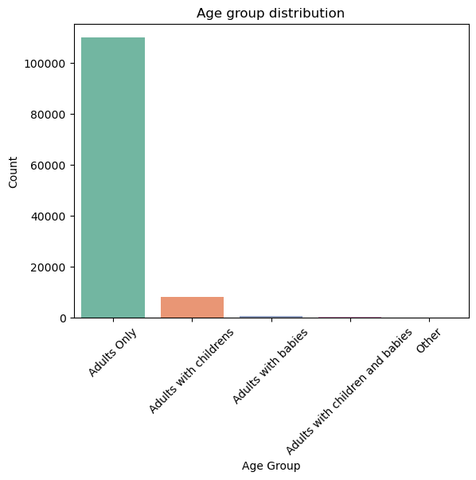

```python
sns.countplot(x='age_group', data = data, hue='age_group', palette='Set2')
plt.title('Age group distribution')
plt.xlabel('Age Group')
plt.ylabel('Count')
plt.xticks(rotation=45)
plt.show()
```

# 3. Revenue Insights

Task 1 Can we figure out which types of bookings bring in the most revenue (room type, stay duration, etc.)?

Task 2 We’re particularly interested in understanding whether there's any difference in revenue based on booking channels (e.g., direct bookings vs. OTA).

```python
data.shape
```

```
(119390, 38)
```

```python
data.head(3)
```

|  | hotel | is_canceled | lead_time | arrival_date_year | arrival_date_month | arrival_date_week_number | arrival_date_day_of_month | stays_in_weekend_nights | stays_in_week_nights | adults | ... | reservation_status | reservation_status_date | name | email | phone-number | credit_card | Year | Month | lead_time_category | age_group |
| --- | --- | --- | --- | --- | --- | --- | --- | --- | --- | --- | --- | --- | --- | --- | --- | --- | --- | --- | --- | --- | --- |
| 0 | Resort Hotel | 0 | 342 | 2015 | July | 27 | 1 | 0 | 0 | 2 | ... | Check-Out | 2015-07-01 | Ernest Barnes | Ernest.Barnes31@outlook.com | 669-792-1661 | ************4322 | 2015 | 7 | NaN | Adults Only |
| 1 | Resort Hotel | 0 | 737 | 2015 | July | 27 | 1 | 0 | 0 | 2 | ... | Check-Out | 2015-07-01 | Andrea Baker | Andrea_Baker94@aol.com | 858-637-6955 | ************9157 | 2015 | 7 | NaN | Adults Only |
| 2 | Resort Hotel | 0 | 7 | 2015 | July | 27 | 1 | 0 | 1 | 1 | ... | Check-Out | 2015-07-02 | Rebecca Parker | Rebecca_Parker@comcast.net | 652-885-2745 | ************3734 | 2015 | 7 | 0-10 days | Adults Only |

3 rows × 38 columns

```python
# columns to be inspected adr,reserved_room_type,assigned_room_type,
```

```python
# To calculate revenue we will need to have total length of stay
data['Total_stay'] = data['stays_in_week_nights'] + data['stays_in_weekend_nights']
```

```python
#calculate revenue for each stay
data['Revenue'] = data['Total_stay'] * data['adr']
data[['Total_stay','Revenue']]
```

|  | Total_stay | Revenue |
| --- | --- | --- |
| 0 | 0 | 0.00 |
| 1 | 0 | 0.00 |
| 2 | 1 | 75.00 |
| 3 | 1 | 75.00 |
| 4 | 2 | 196.00 |
| ... | ... | ... |
| 119385 | 7 | 672.98 |
| 119386 | 7 | 1578.01 |
| 119387 | 7 | 1103.97 |
| 119388 | 7 | 730.80 |
| 119389 | 9 | 1360.80 |

119390 rows × 2 columns

```python
#revenue based on room type
Reserved_Room_Revenue = data.groupby('reserved_room_type')['Revenue'].mean()
Reserved_Room_Revenue
```

```
reserved_room_type
A    286.273672
B    310.231986
C    786.467318
D    485.620689
E    577.960972
F    626.925495
G    778.207039
H    795.021547
L    149.666667
P      0.000000
Name: Revenue, dtype: float64
```

```python
assigned_Room_Revenue = data.groupby('assigned_room_type')['Revenue'].mean()
assigned_Room_Revenue
```

```
assigned_room_type
A    299.821668
B    276.503111
C    482.394762
D    408.133301
E    516.201922
F    544.826132
G    694.744242
H    701.648413
I    144.355152
K    155.945090
L      8.000000
P      0.000000
Name: Revenue, dtype: float64
```

```python
data.columns
```

```
Index(['hotel', 'is_canceled', 'lead_time', 'arrival_date_year',
       'arrival_date_month', 'arrival_date_week_number',
       'arrival_date_day_of_month', 'stays_in_weekend_nights',
       'stays_in_week_nights', 'adults', 'children', 'babies', 'meal',
       'country', 'market_segment', 'distribution_channel',
       'is_repeated_guest', 'previous_cancellations',
       'previous_bookings_not_canceled', 'reserved_room_type',
       'assigned_room_type', 'booking_changes', 'deposit_type',
       'days_in_waiting_list', 'customer_type', 'adr',
       'required_car_parking_spaces', 'total_of_special_requests',
       'reservation_status', 'reservation_status_date', 'name', 'email',
       'phone-number', 'credit_card', 'Year', 'Month', 'lead_time_category',
       'age_group', 'Total_stay', 'Revenue'],
      dtype='object')
```

```python
data['distribution_channel'].unique()
```

```
array(['Direct', 'Corporate', 'TA/TO', 'Undefined', 'GDS'], dtype=object)
```

```python
Revenue_based_on_channel = round(data.groupby('distribution_channel')['Revenue'].mean(),2).reset_index()
Revenue_based_on_channel
```

|  | distribution_channel | Revenue |
| --- | --- | --- |
| 0 | Corporate | 166.86 |
| 1 | Direct | 373.24 |
| 2 | GDS | 238.33 |
| 3 | TA/TO | 368.82 |
| 4 | Undefined | 234.20 |

'''Direct:Guests booking through the hotel's own website, by calling the hotel directly, or making reservations in person. Corporate: Business travelers whose accommodations are arranged by their employer or through a corporate travel agency. TA/TO (Travel Agent/Tour Operator):Agents that help customers book hotels, flights, or complete travel packages, either online or offline. Undefined:Data entries where the source of the booking isn't clearly categorized or is missing. GDS (Global Distribution System):GDS platforms like Amadeus, Sabre, or Galileo that travel agents use to book hotel rooms, flights, and other travel services. '''

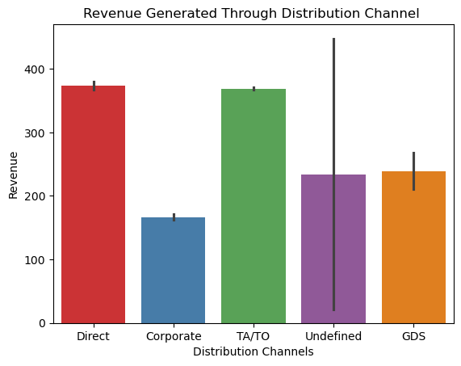

```python
sns.barplot(x = 'distribution_channel', y='Revenue', data= data, hue='distribution_channel',palette='Set1')
plt.title("Revenue Generated Through Distribution Channel ")
plt.xlabel('Distribution Channels')
plt.ylabel('Revenue')
```

```python
total_revenue = data['Revenue'].sum()
total_revenue
```

```
42723497.53
```

# Cancellation count based on distribution channel

```python
data.columns
```

```
Index(['hotel', 'is_canceled', 'lead_time', 'arrival_date_year',
       'arrival_date_month', 'arrival_date_week_number',
       'arrival_date_day_of_month', 'stays_in_weekend_nights',
       'stays_in_week_nights', 'adults', 'children', 'babies', 'meal',
       'country', 'market_segment', 'distribution_channel',
       'is_repeated_guest', 'previous_cancellations',
       'previous_bookings_not_canceled', 'reserved_room_type',
       'assigned_room_type', 'booking_changes', 'deposit_type',
       'days_in_waiting_list', 'customer_type', 'adr',
       'required_car_parking_spaces', 'total_of_special_requests',
       'reservation_status', 'reservation_status_date', 'name', 'email',
       'phone-number', 'credit_card', 'Year', 'Month', 'lead_time_category',
       'age_group', 'Total_stay', 'Revenue'],
      dtype='object')
```

```python
data.groupby('distribution_channel')['is_canceled'].value_counts()
```

```
distribution_channel  is_canceled
Corporate             0               5203
                      1               1474
Direct                0              12088
                      1               2557
GDS                   0                156
                      1                 37
TA/TO                 0              57718
                      1              40152
Undefined             1                  4
                      0                  1
Name: count, dtype: int64
```

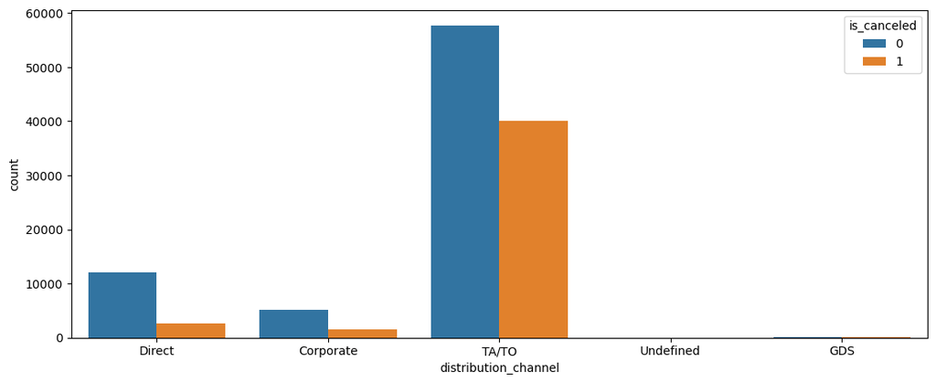

```python
plt.figure(figsize=(13,5))
sns.countplot(x = 'distribution_channel', hue='is_canceled', data = data)
```